# Sparse Kernel Machines

Support Vector Machines

# Support Vector Machines in R

At the end of this lab session, the students are expected to:

1. Explain what a Support Vector Machine (SVM) is and identify its main ingredient.
2. Be able to run SVM using the package `kernlab`.
3. Perform numerical experiments to see how varying SVM parameters affect its parameters.

# Introduction to SVM

Support Vector Machines are one of the most popular classifiers today. When you have a problem and it is about classifying objects (or instances), you should perhaps try SVMs. The idea behind SVMs is to define a boundary between classes. The boundary must separate the closest points as far as possible. The separation is controlled by what is called the margin (see Figure 1). For SVM the margin is made as wide as possible. SVMs have many desirable properties:

1. They perform well on many classification tasks.
2. They avoid the curse of dimensionality.
3. They have nice theoretical properties.

The main ingredient in SVMs are the kernel functions which computes the dot product of objects in some feature space. Kernel functions allow SVMs to model complex boundaries (e.g. circular). Watch this (video)[https://www.youtube.com/watch?v=3liCbRZPrZA] to get an intuitive understanding of how kernel works. A full treatment of SVMs will be covered in the lecture.

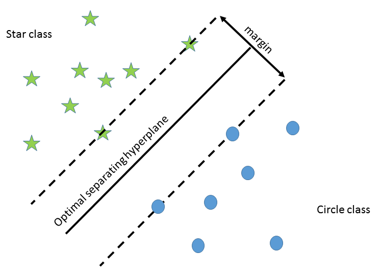

Figure 1

Figure 1 shows two classes separated by a hyperplane. The hyperplane is constructed by applying SVM. The distance between the closest points is called the *margin*. Objects near the boundary are called *support vectors*.

# Lab Session

For this lab session we are going to experiment with SVMs by playing with its parameters. For classification, SVMs have only two parameters: the kernel function and the cost of misclassification. The cost is added to penalize misclassifications. Sometimes the kernel function also has parameters, we need to optimize them as well. We will use the `kernlab` package in `R` to train SVMs. Here the steps:

1. Install and load the kernlab package

```r
# install.packages("kernlab")
library(kernlab)

# Load other libraries
library(data.table)
library(ggplot2)
```

2. Import the amazon data. You can download the data in Blackboard. The amazon data is in the zip file.

```r
amazon_sentences <- fread( "amazon_cells_labelled.txt", header=FALSE, sep="\t")
```

3. Preprocess the data. Extract text features and attach the sentiment. The column containing the sentiment should be named *sentiment*. Supply the necessary code.
4. Split the data into train and test (preferably make a 80-20 split). Name the training data *train_do* and the test data *test_do*. Supply the necessary code.

Train an SVM, set the misclassification cost equal to 10 and use the dot product kernel.

```r
# Train the model
do_model<-ksvm(sentiment~., data=train_do, kernel="vanilladot",
kpar="automatic", C=10, cross=10)
```

> Q1: How many support vectors are there? (Hint: Explore the ksvm function to find where the support vectors are stored)
5. Use the trained model to predict the classes of objects in the test set

```r
predict(do_model, test_do[,-1838])
```

6. Compute the accuracy

```r
accu<-sum(predict(do_model, test_do[,-1838])== test_do$sentiment)/dim(test_do)[1] * 100

print(paste0("The accuracy is ", accu, "%"))
```

```
## [1] "The accuracy is 82.5%"
```

Now, we will experiment with different values of `C` (i.e. the misclassification cost). We will vary `C`.

Complete the code below

```r
mis_cost <- 10^seq(-2,2, by=0.1)

pred_accu <- function(miscost){
              mod<-ksvm(sentiment~., data=train_do, kernel="vanilladot", C=miscost, cross=10)
              "add your code here to return the accuracy"
}

# Store the misclassification costs with their associated predictive accuracy
VDP <- sapply(mis_cost,pred_accu)
```

> Q2: What is the optimal cost?

Now vary C and the kernel function simultaneously. Specifically, try the radial basis function (sigma=0.05), ordinary dot product and second-order polynomial (scaling =1 and offset =1).

Let us find the “best” combination of `C` and kernel function. Provide the code.

> Q3: What is the best combination of misclassification cost and kernel function?

Vladimer Kobayashi

2017-11-29